# Week 26. T-test Exercise

Dinkar Sharma, Lazaros Gonidis

18/01/2022

# Introduction

In today’s session we want you to revisit the *t*-test methods you used in your Stage 1. Use the **Stress.csv** data file and the appropriate arguments for the **t_test()** function. Before doing that have a look at the brief refresher below on how to check the t-test assumptions and we carry out the appropriate t-test.

## T-test preliminary steps and assumptions

1. Normality assumption  
   1.1 Shapiro test  
   1.2 qq-plot  
   1.3 Skewness and Kurtosis
2. Equal variance assumption  
   2.1 Calculate variance or standard deviation  
   2.2 Levene’s test
3. Carry out the appropriate t-test

### Let us have a look at how we can carry out these checks using the datafile **student t test.csv**.

```r
library(rstatix)
library(tidyverse)
library(ggpubr)

### load file
df <- read_csv("student t test.csv")

### group as factor
df$group <- as.factor(df$group)

### descriptives
group_by(df, group) %>%
  get_summary_stats(performance, type = "mean_sd") %>%
  ungroup()
```

```
## # A tibble: 2 x 5
##   group variable        n  mean    sd
##   <fct> <chr>       <dbl> <dbl> <dbl>
## 1 1     performance    50  605.  92.2
## 2 2     performance    50  813.  91.3
```

```r
### check whether our scores are normally distributed
### using Shapiro-Wilk test
### p values above 0.05 indicate normally distributed scores
df %>%
  group_by(group) %>%
  shapiro_test(performance) %>% ### Checks for normality
  ungroup()
```

```
## # A tibble: 2 x 4
##   group variable    statistic     p
##   <fct> <chr>           <dbl> <dbl>
## 1 1     performance     0.992 0.979
## 2 2     performance     0.991 0.966
```

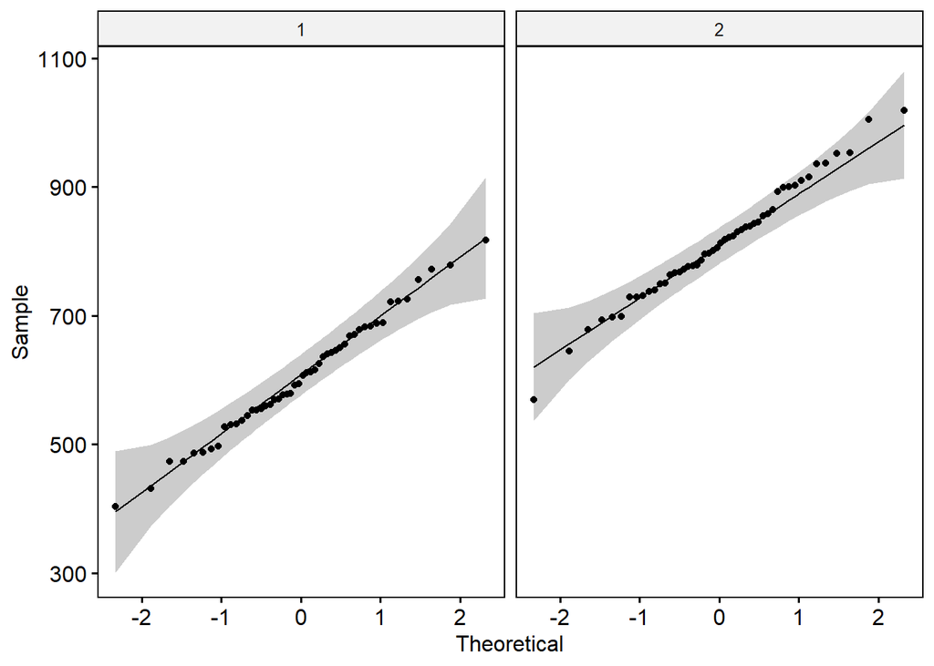

```r
### For Shapiro Wilk test we want to see p values above 0.05
### if both p values come back above 0.05 then you can proceed


### we can also inspect for normality using a qq plot
### this is a plot that show how our scores are correlated
### to a normal distribution
### visually if all our scores fall into the grey area indicate
### that they are normally distributed

ggqqplot(df, x = "performance", facet.by = "group")
```

```r
### we can also get skewness and kurtosis information
### for that we need to have installed the moments package

### make sure  you install the package moments before proceeding

### you can do so by running install.packages("moments")
### you should run this line only once
library(moments)

df %>%
  group_by(group) %>%
  summarise(Skew = skewness(performance, na.rm = TRUE),
            Kurt = kurtosis(performance, na.rm = TRUE)) %>%
  ungroup()
```

```
## # A tibble: 2 x 3
##   group    Skew  Kurt
##   <fct>   <dbl> <dbl>
## 1 1     0.122    2.60
## 2 2     0.00319  3.08
```

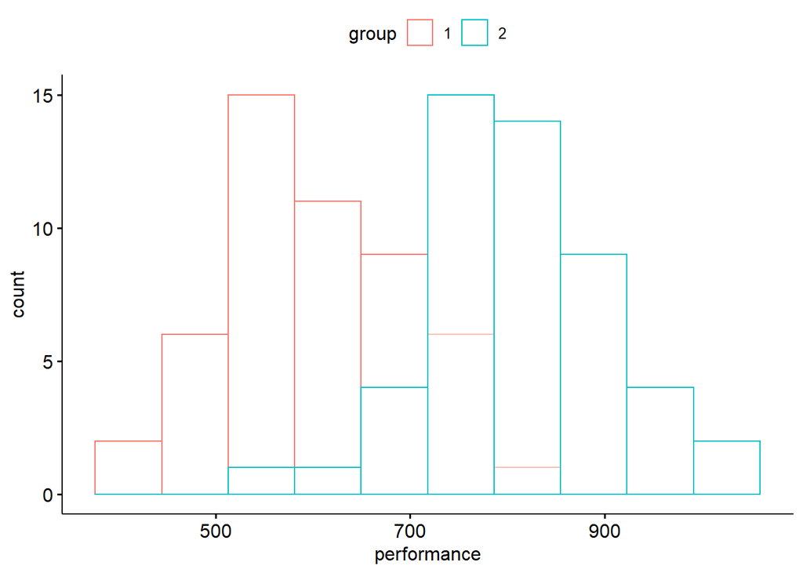

```r
### for normality we are looking for skewness values
### between 2 and -2 and kurtosis between -7 and 7
### the argument na.rm = TRUE removes missing values
### if there are missing values and we do not remove them
### the function will return NA (no answer)


### we can also inspect visually by looking at histograms
gghistogram(df, "performance", bins = 10, color = "group")
```

```r
### check for equal variances
### p value above 0.05 indicate no violation of the assumption
### of equal variance

levene_test(df, performance ~ group)  ### performance by group
```

```
## # A tibble: 1 x 4
##     df1   df2 statistic     p
##   <int> <int>     <dbl> <dbl>
## 1     1    98    0.0891 0.766
```

```r
### If Levene's test returns a p-value above 0.05 then my assumption
### of equal variance is not violated.
### time for the t-test statistic calculation
### var.equal = TRUE declares that we have equal variance
### therefore we can use Student's t-test
### var.equal = FALSE declares that we have unequal variance
### therefore we should use Welch's t-test
```

By looking at our output we see that the two groups are normally distributed and have equal variance. We will therefore run **Student’s t-test**. We do that by using the argument `var.equal = TRUE`. It is also worth noting here that our example above utilised a between-participants design. If we wanted to carry out a t-test for within-participants data then all we had to do was to add the argument `paired = TRUE`.

```r
t_test(df, performance~group, var.equal = TRUE)
```

```
## # A tibble: 1 x 8
##   .y.         group1 group2    n1    n2 statistic    df        p
## * <chr>       <chr>  <chr>  <int> <int>     <dbl> <dbl>    <dbl>
## 1 performance 1      2         50    50     -11.3    98 1.77e-19
```

# Task 1

For Task 1 you will need to work with the datafile **stress.sav**. You can find the file on Moodle in the folder called **ALL WEEKS - R files for computing exercises**. This is an SPSS datafile so make sure you use the correct package to load it as a dataframe.  
Once you load the file make sure that grouping variables are correctly identified as factors (hint: `as.factor()`)

```r
### the haven package allows you to read SPSS datafiles
### make sure to install the haven package before using library

library(haven)
df <- read_sav("stress.sav")
```

Here we are going to test whether or not there is a difference in the overall stress levels at time one and time two. Before doing this, you must obtain descriptive statistics (Mean, Standard deviation, Variance, Kurtosis and Skewness) for STRESS1 and STRESS2 and produce a histogram for each of the variables. Once these statistics and histograms have been generated, carry out the repeated measures **t-test**.

Q1) Will you be using a paired-samples or an independent-samples t-test?

Q2) Which argument did you use for running the correct t-test?

Q3) What are the assumptions of this test and judging from the histograms and variances, to what extent are these assumptions violated by the data?

Q4) What is the Null Hypothesis for this test?

Q5) Can it be rejected?________. Fill in : t ( ) = ______, ______

# Task 2:

We are now going to test whether there is a difference in stress levels between males (gender=1) and females (gender=2) at time 1 (an independent t-test). Carry out the appropriate checks and t-test in order to answer the following questions.

Q1) What are the assumptions of this test and judging from the histograms, descriptive information and Levene’s test, to what extent are they violated by the data?

Q2) Which arguments will you use within your **t_test()**?

Q3) What is the Null Hypothesis for this test?

Q4) Can it be rejected?________. Fill in : t ( ) = ______, ______.

# Task 3

For this task, you are required to carry out a t-test investigating the difference between stress levels at time 1 and stress levels at time 2 but only with patients (role=1)

Q1) What sort of t-test are you using here and what is it doing?

Q2) To what extent are the test’s assumptions violated by the data here?

Q3) What is the Null Hypothesis for this test?

Q4) Can it be rejected?________. Fill in : t ( ) = ______, ______

# Task 4

Once you have finished task 3, make sure you are now working on all the data. Now produce descriptive statistics and histograms for patients (role=1) and spouses (role=2) at time 1. Use the appropriate t-test to compare these two conditions at time 1.

Q1) What sort of t-test are you using and what is it doing?

Q2) To what extent are the test’s assumptions violated by the data? Q3) What is the Null Hypothesis for this test?

Q4) Can it be rejected?________. Fill in : t ( ) = ______, ______

# Answers

## Task 1

In order to run the required analysis we need to bring the datafile to long format. Furthermore, for paired-samples *t*-test we do not check for normality. However, we can draw histograms for visual inspection.

Q1) We will be using a paired samples *t*-test

Q2) We have to use the argument `paired = TRUE`

Q3) Our scores need to be normally distributed with equal variance

Q4) The two means are equal

Q5) Yes we can reject the null hypothesis. *t*(97) = 2.26, p = .026

## Task 1 Analysis Code

```r
library(rstatix)
library(tidyverse)
library(ggpubr)
library(haven)

### load file
df <- read_sav("stress.sav")

## as our datafile is in wide format we need to bring it long format

library(tidyverse)

df_long1 <- pivot_longer(df, cols = stress1:stress2, names_to = "session", values_to = "score")

df_long1
```

```
## # A tibble: 356 x 6
##      fno    gender        role             cond session                  score
##    <dbl> <dbl+lbl>   <dbl+lbl>        <dbl+lbl> <chr>                <dbl+lbl>
##  1   104  1 [male] 1 [Patient] 1 [male patient] stress1  4 [quite high stress]
##  2   104  1 [male] 1 [Patient] 1 [male patient] stress2 NA
##  3   105  1 [male] 1 [Patient] 1 [male patient] stress1  3 [avarage stress]
##  4   105  1 [male] 1 [Patient] 1 [male patient] stress2  4 [quite high stress]
##  5   108  1 [male] 1 [Patient] 1 [male patient] stress1  1 [very low Stress]
##  6   108  1 [male] 1 [Patient] 1 [male patient] stress2  2 [quite low stress]
##  7   110  1 [male] 1 [Patient] 1 [male patient] stress1  2 [quite low stress]
##  8   110  1 [male] 1 [Patient] 1 [male patient] stress2  3 [avarage stress]
##  9   113  1 [male] 1 [Patient] 1 [male patient] stress1  2 [quite low stress]
## 10   113  1 [male] 1 [Patient] 1 [male patient] stress2  3 [avarage stress]
## # ... with 346 more rows
```

```r
### set time as factor variable

df_long1$session <- as.factor(df_long1$session)


### descriptives
group_by(df_long1, session) %>%
  get_summary_stats(score, type = "mean_sd") %>%
  ungroup()
```

```
## # A tibble: 2 x 5
##   session variable     n  mean    sd
##   <fct>   <chr>    <dbl> <dbl> <dbl>
## 1 stress1 score      175  3.17  1.03
## 2 stress2 score      100  2.9   1.09
```

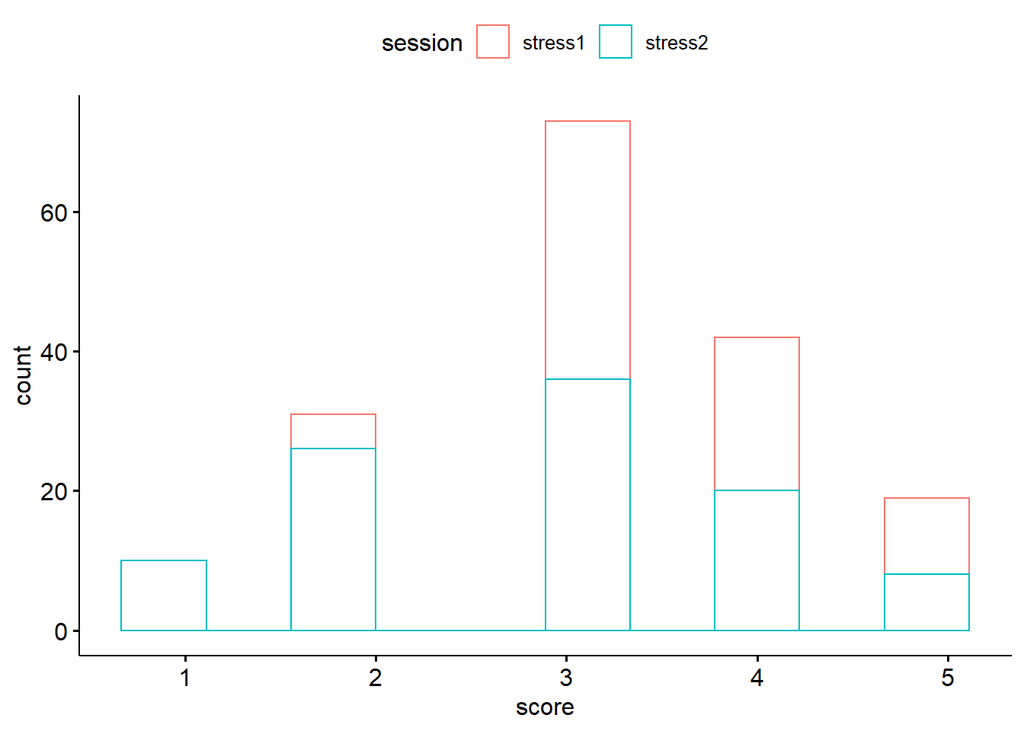

```r
### we can inspect visually by looking at histograms
gghistogram(df_long1, "score", bins = 10, color = "session")
```

```r
### we can also get skewness and kurtosis information

library(moments)

df_long1 %>%
  group_by(session) %>%
  summarise(Skew = skewness(score, na.rm = TRUE),
            Kurt = kurtosis(score, na.rm = TRUE)) %>%
  ungroup()
```

```
## # A tibble: 2 x 3
##   session    Skew  Kurt
##   <fct>     <dbl> <dbl>
## 1 stress1 -0.0496  2.64
## 2 stress2  0.104   2.43
```

```r
### for normality we are looking for skewness values
### between 2 and -2


### check for equal variances
### p value above 0.05 indicate no violation of the assumption
### of equal variance

levene_test(df_long1, score ~ session)  ### performance by group
```

```
## # A tibble: 1 x 4
##     df1   df2 statistic     p
##   <int> <int>     <dbl> <dbl>
## 1     1   273     0.626 0.430
```

```r
### carry out the t-test using paired = TRUE
t_test(df_long1, score~session, var.equal = TRUE, paired = TRUE)
```

```
## # A tibble: 1 x 8
##   .y.   group1  group2     n1    n2 statistic    df      p
## * <chr> <chr>   <chr>   <int> <int>     <dbl> <dbl>  <dbl>
## 1 score stress1 stress2   178   178      2.26    97 0.0262
```

## Task 2

Q1) We will be using an independent samples *t*-test

Q3) The two means are equal.

## Task 2 Analysis Code

```r
library(rstatix)
library(tidyverse)
library(ggpubr)
library(haven)



### We will continue working with df_long1

df_long1$gender <- as.factor(df_long1$gender)

### descriptives
group_by(df_long1, gender) %>%
  get_summary_stats(score, type = "mean_sd") %>%
  ungroup()
```

```
## # A tibble: 2 x 5
##   gender variable     n  mean    sd
##   <fct>  <chr>    <dbl> <dbl> <dbl>
## 1 1      score      114  2.92 0.979
## 2 2      score      161  3.17 1.10
```

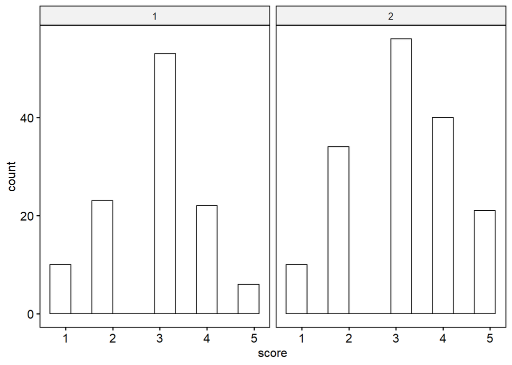

```r
### we can inspect visually by looking at histograms
gghistogram(df_long1, "score", bins = 10, facet.by = "gender")
```

```r
### we can also get skewness and kurtosis information

library(moments)

df_long1 %>%
  group_by(gender) %>%
  summarise(Skew = skewness(score, na.rm = TRUE),
            Kurt = kurtosis(score, na.rm = TRUE)) %>%
  ungroup()
```

```
## # A tibble: 2 x 3
##   gender    Skew  Kurt
##   <fct>    <dbl> <dbl>
## 1 1      -0.0691  2.86
## 2 2      -0.0360  2.33
```

```r
### for normality we are looking for skewness values
### between 2 and -2


### check for equal variances
### p value above 0.05 indicate no violation of the assumption
### of equal variance

levene_test(df_long1, score ~ gender)  ### performance by group
```

```
## # A tibble: 1 x 4
##     df1   df2 statistic      p
##   <int> <int>     <dbl>  <dbl>
## 1     1   273      3.73 0.0546
```

```r
### carry out the t-test using paired = TRUE
t_test(df_long1, score~gender, var.equal = TRUE)
```

```
## # A tibble: 1 x 8
##   .y.   group1 group2    n1    n2 statistic    df      p
## * <chr> <chr>  <chr>  <int> <int>     <dbl> <dbl>  <dbl>
## 1 score 1      2        146   210     -1.97   273 0.0503
```

## Task 3

Q1) Paired-sampled *t*-test comparing the scores between session 1 and session 2 but only for patients. To do that we retained only the rows of df_long1 that had role equal to 1. Remember this is a logical comparison therefore we used `==`.

Q2) The assumptions seem to hold.

Q3) That the means are equal

Q4) Yes we can reject the null hypothesis. *t*(61) = 2.14, *p* = .037

## Task 3 Analysis Code

```r
library(rstatix)
library(tidyverse)
library(ggpubr)
library(haven)

df_long3 <- filter(df_long1, role == 1)

df_long3
```

```
## # A tibble: 208 x 6
##      fno gender        role             cond session                  score
##    <dbl> <fct>    <dbl+lbl>        <dbl+lbl> <fct>                <dbl+lbl>
##  1   104 1      1 [Patient] 1 [male patient] stress1  4 [quite high stress]
##  2   104 1      1 [Patient] 1 [male patient] stress2 NA
##  3   105 1      1 [Patient] 1 [male patient] stress1  3 [avarage stress]
##  4   105 1      1 [Patient] 1 [male patient] stress2  4 [quite high stress]
##  5   108 1      1 [Patient] 1 [male patient] stress1  1 [very low Stress]
##  6   108 1      1 [Patient] 1 [male patient] stress2  2 [quite low stress]
##  7   110 1      1 [Patient] 1 [male patient] stress1  2 [quite low stress]
##  8   110 1      1 [Patient] 1 [male patient] stress2  3 [avarage stress]
##  9   113 1      1 [Patient] 1 [male patient] stress1  2 [quite low stress]
## 10   113 1      1 [Patient] 1 [male patient] stress2  3 [avarage stress]
## # ... with 198 more rows
```

```r
### descriptives
group_by(df_long3, session) %>%
  get_summary_stats(score, type = "mean_sd") %>%
  ungroup()
```

```
## # A tibble: 2 x 5
##   session variable     n  mean    sd
##   <fct>   <chr>    <dbl> <dbl> <dbl>
## 1 stress1 score      104  3.08  1.09
## 2 stress2 score       62  2.76  1.02
```

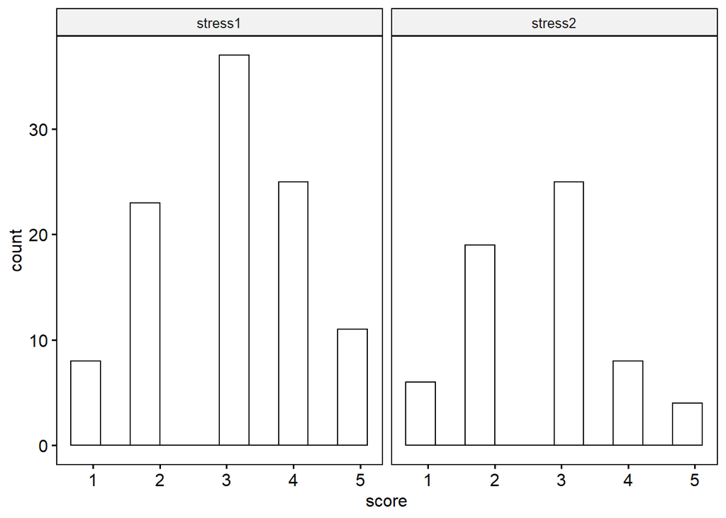

```r
### we can inspect visually by looking at histograms
gghistogram(df_long3, "score", bins = 10, facet.by = "session")
```

```r
### we can also get skewness and kurtosis information

library(moments)

df_long3 %>%
  group_by(session) %>%
  summarise(Skew = skewness(score, na.rm = TRUE),
            Kurt = kurtosis(score, na.rm = TRUE)) %>%
  ungroup()
```

```
## # A tibble: 2 x 3
##   session    Skew  Kurt
##   <fct>     <dbl> <dbl>
## 1 stress1 -0.0188  2.38
## 2 stress2  0.310   2.84
```

```r
### for normality we are looking for skewness values
### between 2 and -2


### check for equal variances
### p value above 0.05 indicate no violation of the assumption
### of equal variance

levene_test(df_long3, score ~ session)  ### performance by group
```

```
## # A tibble: 1 x 4
##     df1   df2 statistic     p
##   <int> <int>     <dbl> <dbl>
## 1     1   164     0.358 0.550
```

```r
### carry out the t-test using paired = TRUE
t_test(df_long3, score~session, var.equal = TRUE, paired = TRUE)
```

```
## # A tibble: 1 x 8
##   .y.   group1  group2     n1    n2 statistic    df      p
## * <chr> <chr>   <chr>   <int> <int>     <dbl> <dbl>  <dbl>
## 1 score stress1 stress2   104   104      2.14    61 0.0365
```

## Task 4

Q1) We will be using an independent samples *t*-test to compare patients and spouses, but only for at session 1. We will therefore, use filter again but for session this time.

Q3) There is no difference between the means

Q4) No it cannot be rejected. *t*(173) = -1.39, *p* = .168

## Task 4 Analysis Code

```r
library(rstatix)
library(tidyverse)
library(ggpubr)
library(haven)


### select only the stress1 time
df_long4 <- filter(df_long1, session == "stress1")

df_long4$role <-as.factor(df_long4$role)

### descriptives
group_by(df_long4, role) %>%
  get_summary_stats(score, type = "mean_sd") %>%
  ungroup()
```

```
## # A tibble: 2 x 5
##   role  variable     n  mean    sd
##   <fct> <chr>    <dbl> <dbl> <dbl>
## 1 1     score      104  3.08 1.09
## 2 2     score       71  3.30 0.916
```

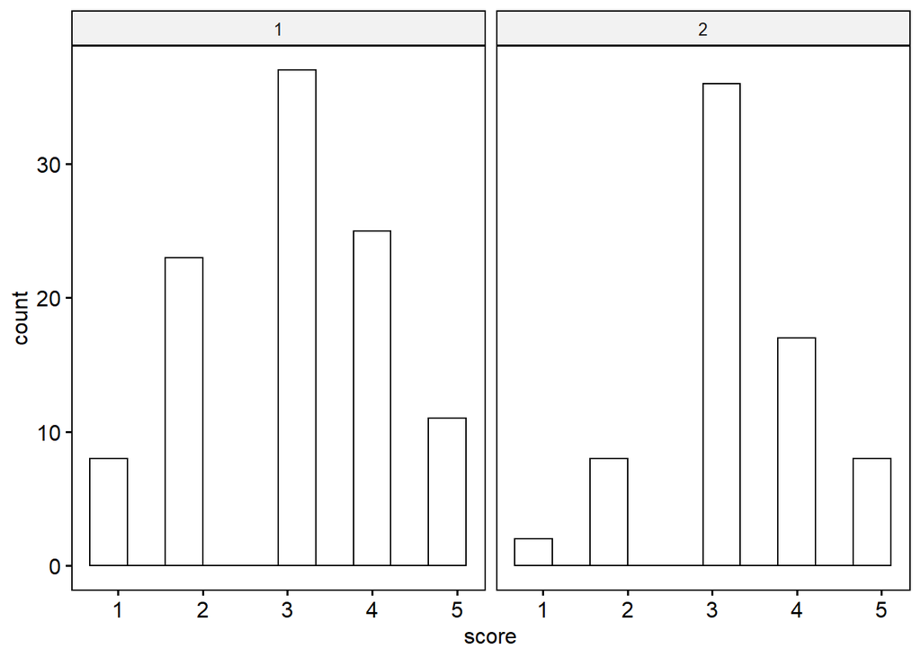

```r
### we can inspect visually by looking at histograms
gghistogram(df_long4, "score", bins = 10, facet.by = "role")
```

```r
### check whether our scores are normally distributed
### using Shapiro-Wilk test
### p values above 0.05 indicate normally distributed scores
df_long4 %>%
  group_by(role) %>%
  shapiro_test(score) %>% ### Checks for normality
  ungroup()
```

```
## # A tibble: 2 x 4
##   role  variable statistic          p
##   <fct> <chr>        <dbl>      <dbl>
## 1 1     score        0.916 0.00000625
## 2 2     score        0.876 0.00000424
```

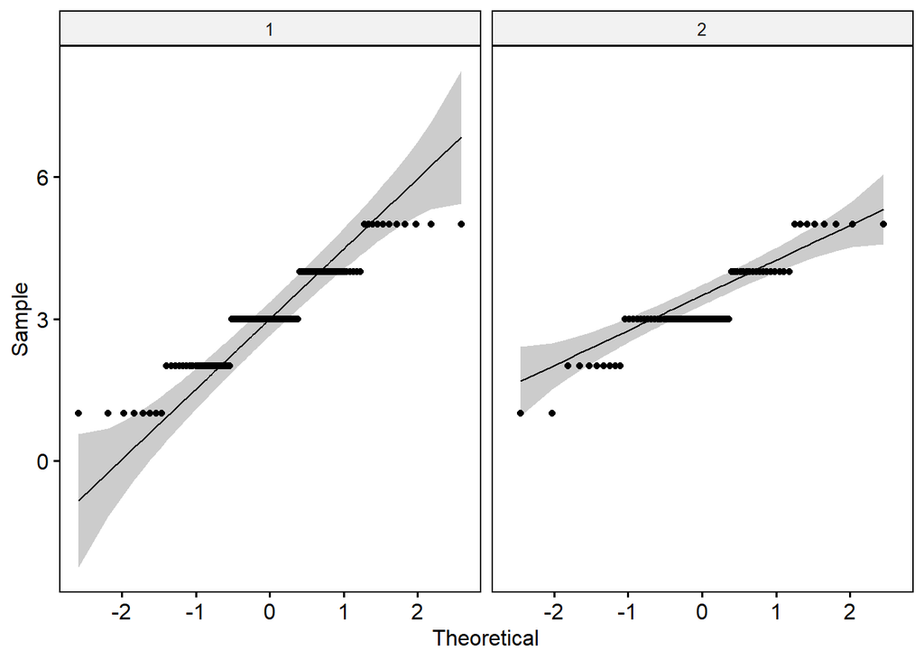

```r
### For Shapiro Wilk test we want to see p values above 0.05
### if both p values come back above 0.05 then you can proceed


### we can also inspect for normality using a qq plot
### this is a plot that show how our scores are correlated
### to a normal distribution
### visually if all our scores fall into the grey area indicate
### that they are normally distributed

ggqqplot(df_long4, x = "score", facet.by = "role")
```

```r
### we can also get skewness and kurtosis information

library(moments)

df_long4 %>%
  group_by(role) %>%
  summarise(Skew = skewness(score, na.rm = TRUE),
            Kurt = kurtosis(score, na.rm = TRUE)) %>%
  ungroup()
```

```
## # A tibble: 2 x 3
##   role     Skew  Kurt
##   <fct>   <dbl> <dbl>
## 1 1     -0.0188  2.38
## 2 2      0.0560  3.08
```

```r
### check for equal variances
### p value above 0.05 indicate no violation of the assumption
### of equal variance

levene_test(df_long4, score ~ role)  ### performance by group
```

```
## # A tibble: 1 x 4
##     df1   df2 statistic      p
##   <int> <int>     <dbl>  <dbl>
## 1     1   173      3.05 0.0827
```

```r
### carry out the t-test using paired = TRUE
t_test(df_long4, score~role, var.equal = TRUE)
```

```
## # A tibble: 1 x 8
##   .y.   group1 group2    n1    n2 statistic    df     p
## * <chr> <chr>  <chr>  <int> <int>     <dbl> <dbl> <dbl>
## 1 score 1      2        104    74     -1.39   173 0.168
```